# Bella Beat

Maike

22/09/2021

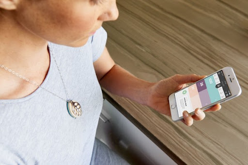

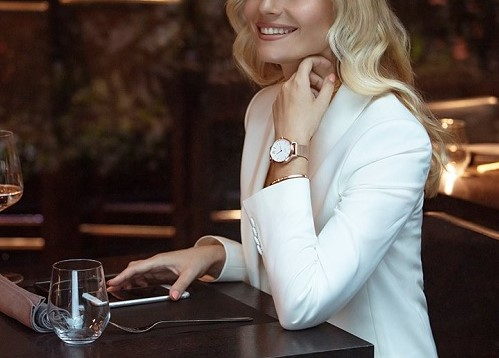

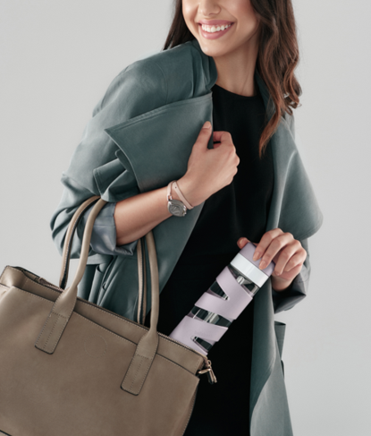

[figure not shown]

```r
library(dplyr)
library(tidyr)
library(lubridate)
library(magrittr)
library(padr)
library(ggplot2)
library(gridExtra)
```

# 1. Import Data

## Daily

```r
file_path <- 'data/Fitabase Data 4.12.16-5.12.16'

# Daily data
activity_daily <-
  read.csv(paste(file_path, 'dailyActivity_merged.csv', sep = '/'))
calories_daily <-
  read.csv(paste(file_path, 'dailyCalories_merged.csv', sep = '/'))
intensities_daily <-
  read.csv(paste(file_path, 'dailyIntensities_merged.csv', sep = '/'))
steps_daily <-
  read.csv(paste(file_path, 'dailySteps_merged.csv', sep = '/'))
sleep_daily <-
  read.csv(paste(file_path, 'sleepDay_merged.csv', sep = '/'))
```

## Hourly

```r
# Hourly data
calories_hourly <-
  read.csv(paste(file_path, 'hourlyCalories_merged.csv', sep = '/'))
intensities_hourly <-
  read.csv(paste(file_path, 'hourlyIntensities_merged.csv', sep = '/'))
steps_hourly <-
  read.csv(paste(file_path, 'hourlySteps_merged.csv', sep = '/'))
```

## Every minute

```r
# Every minute data
caloriesNarrow_minute <-
  read.csv(paste(file_path, 'minuteCaloriesNarrow_merged.csv', sep = '/'))
caloriesWide_minute <-
  read.csv(paste(file_path, 'minuteCaloriesWide_merged.csv', sep = '/'))
intensitiesNarrow_minute <-
  read.csv(paste(file_path, 'minuteIntensitiesNarrow_merged.csv', sep = '/'))
intensitiesWide_minute <-
  read.csv(paste(file_path, 'minuteIntensitiesWide_merged.csv', sep = '/'))
stepsNarrow_minute <-
  read.csv(paste(file_path, 'minuteStepsNarrow_merged.csv', sep = '/'))
stepsWide_minute <-
  read.csv(paste(file_path, 'minuteStepsWide_merged.csv', sep = '/'))
sleep_minute <-
  read.csv(paste(file_path, 'minuteSleep_merged.csv', sep = '/'))
metabolic_minute <-
  read.csv(paste(file_path, 'minuteMETsNarrow_merged.csv', sep = '/'))
```

## Other frequencies

```r
# Others
weight_log <-
  read.csv(paste(file_path, 'weightLogInfo_merged.csv', sep = '/'))
heartrate_seconds <-
  read.csv(paste(file_path, 'heartrate_seconds_merged.csv', sep = '/'))
```

# 2. Prepare Data

Using **Excel/Google Sheets** and looking at data, we can have some first impression of data like size, format, content. Before exploring data in more detail, we can prepare some data based on this first impressions.

First of all, we have three main types of datasets: daily data, hourly data, minute data. **Sleep**, **Heart rate** and **METs** (Metabolic Equivalents), are not available in minutes, hourly, or daily datasets. So we’ll resample these datasets by minutes, hours, and days, hence having more data to compare.

## Sleep data

```r
# Convert 'date' column to 'POSIXct' type
sleep_minute %<>% mutate(date = parse_date_time(date, "%m/%d/%Y %H:%M:%S %p"))

# Create a new df by resampling by average of 'value'


# Using summarise, by mean, max, min, the column 'value' has no meaning, but if we count the values of each hour, seems to be number of minutes in bed, with a lot of '60' values. So i just assume that 'value' column means 'TimeInBed'
sleep_hourly <-
  sleep_minute %>% thicken('hour') %>% group_by(Id, date_hour) %>% summarise(MinutesInBed = sum(value / value))
```

## Heart rate data

```r
# Convert 'Time' column to 'POSIXct' type
heartrate_seconds %<>% mutate(Time = parse_date_time(Time, "%m/%d/%Y %H:%M:%S %p"))

# Create a new df by resample average, max, and min 'heartrate' per minute
heartrate_minute <-
  heartrate_seconds %>% thicken("min") %>% group_by(Id, Time_min) %>% summarise(
    AverageBPM = mean(Value),
    MaxBPM = max(Value),
    MinBPM = min(Value)
  )

# Create a new df by resample average, max, and min heartrate per hour
heartrate_hourly <-
  heartrate_seconds %>% thicken("hour") %>% group_by(Id, Time_hour) %>% summarise(
    AverageBPM = mean(Value),
    MaxBPM = max(Value),
    MinBPM = min(Value)
  )

# Create a new df by resample average, max, and min heartrate per day
heartrate_daily <-
  heartrate_seconds %>% thicken("day") %>% group_by(Id, Time_day) %>% summarise(
    AverageBPM = mean(Value),
    MaxBPM = max(Value),
    MinBPM = min(Value)
  )
```

## Metabolic data

```r
# Convert 'ActivityMinute' column to 'POSIXct' type
metabolic_minute %<>% mutate(ActivityMinute = parse_date_time(ActivityMinute, "%m/%d/%Y %H:%M:%S %p"))

# Metabolic equivalent is mensured on a scale from 0 to >10. I will infer this data is scale by 10x
metabolic_minute %<>% mutate(METs = METs/10)

metabolic_hourly <-
  metabolic_minute %>% thicken('hour') %>% group_by(Id, ActivityMinute_hour) %>% summarise(
    AverageMETs = mean(METs),
    MaxMETs = max(METs),
    Min_METs = min(METs)
  )

metabolic_daily <-
  metabolic_minute %>% thicken('day') %>% group_by(Id, ActivityMinute_day) %>% summarise(
    AverageMETs = mean(METs),
    MaxMETs = max(METs),
    MinMETs = min(METs)
  )
```

# Let’s look at **daily** data!

Now, I’m going to look at the datasets and figure out the best way to handle them.

### Activity dataset

```r
as_tibble(activity_daily)
```

```
## # A tibble: 940 x 15
##            Id ActivityDate TotalSteps TotalDistance TrackerDistance LoggedActivitie~
##         <dbl> <chr>             <int>         <dbl>           <dbl>            <dbl>
##  1 1503960366 4/12/2016         13162          8.5             8.5                 0
##  2 1503960366 4/13/2016         10735          6.97            6.97                0
##  3 1503960366 4/14/2016         10460          6.74            6.74                0
##  4 1503960366 4/15/2016          9762          6.28            6.28                0
##  5 1503960366 4/16/2016         12669          8.16            8.16                0
##  6 1503960366 4/17/2016          9705          6.48            6.48                0
##  7 1503960366 4/18/2016         13019          8.59            8.59                0
##  8 1503960366 4/19/2016         15506          9.88            9.88                0
##  9 1503960366 4/20/2016         10544          6.68            6.68                0
## 10 1503960366 4/21/2016          9819          6.34            6.34                0
## # ... with 930 more rows, and 9 more variables: VeryActiveDistance <dbl>,
## #   ModeratelyActiveDistance <dbl>, LightActiveDistance <dbl>,
## #   SedentaryActiveDistance <dbl>, VeryActiveMinutes <int>,
## #   FairlyActiveMinutes <int>, LightlyActiveMinutes <int>,
## #   SedentaryMinutes <int>, Calories <int>
```

### Calories dataset

```r
as_tibble(calories_daily)
```

```
## # A tibble: 940 x 3
##            Id ActivityDay Calories
##         <dbl> <chr>          <int>
##  1 1503960366 4/12/2016       1985
##  2 1503960366 4/13/2016       1797
##  3 1503960366 4/14/2016       1776
##  4 1503960366 4/15/2016       1745
##  5 1503960366 4/16/2016       1863
##  6 1503960366 4/17/2016       1728
##  7 1503960366 4/18/2016       1921
##  8 1503960366 4/19/2016       2035
##  9 1503960366 4/20/2016       1786
## 10 1503960366 4/21/2016       1775
## # ... with 930 more rows
```

### Intensities dataset

```r
as_tibble(intensities_daily)
```

```
## # A tibble: 940 x 10
##            Id ActivityDay SedentaryMinutes LightlyActiveMinutes FairlyActiveMin~
##         <dbl> <chr>                  <int>                <int>            <int>
##  1 1503960366 4/12/2016                728                  328               13
##  2 1503960366 4/13/2016                776                  217               19
##  3 1503960366 4/14/2016               1218                  181               11
##  4 1503960366 4/15/2016                726                  209               34
##  5 1503960366 4/16/2016                773                  221               10
##  6 1503960366 4/17/2016                539                  164               20
##  7 1503960366 4/18/2016               1149                  233               16
##  8 1503960366 4/19/2016                775                  264               31
##  9 1503960366 4/20/2016                818                  205               12
## 10 1503960366 4/21/2016                838                  211                8
## # ... with 930 more rows, and 5 more variables: VeryActiveMinutes <int>,
## #   SedentaryActiveDistance <dbl>, LightActiveDistance <dbl>,
## #   ModeratelyActiveDistance <dbl>, VeryActiveDistance <dbl>
```

### Steps dataset

```r
as_tibble(steps_daily)
```

```
## # A tibble: 940 x 3
##            Id ActivityDay StepTotal
##         <dbl> <chr>           <int>
##  1 1503960366 4/12/2016       13162
##  2 1503960366 4/13/2016       10735
##  3 1503960366 4/14/2016       10460
##  4 1503960366 4/15/2016        9762
##  5 1503960366 4/16/2016       12669
##  6 1503960366 4/17/2016        9705
##  7 1503960366 4/18/2016       13019
##  8 1503960366 4/19/2016       15506
##  9 1503960366 4/20/2016       10544
## 10 1503960366 4/21/2016        9819
## # ... with 930 more rows
```

### Sleep dataset

```r
as_tibble(sleep_daily)
```

```
## # A tibble: 413 x 5
##            Id SleepDay              TotalSleepRecor~ TotalMinutesAsl~ TotalTimeInBed
##         <dbl> <chr>                            <int>            <int>          <int>
##  1 1503960366 4/12/2016 12:00:00 AM                1              327            346
##  2 1503960366 4/13/2016 12:00:00 AM                2              384            407
##  3 1503960366 4/15/2016 12:00:00 AM                1              412            442
##  4 1503960366 4/16/2016 12:00:00 AM                2              340            367
##  5 1503960366 4/17/2016 12:00:00 AM                1              700            712
##  6 1503960366 4/19/2016 12:00:00 AM                1              304            320
##  7 1503960366 4/20/2016 12:00:00 AM                1              360            377
##  8 1503960366 4/21/2016 12:00:00 AM                1              325            364
##  9 1503960366 4/23/2016 12:00:00 AM                1              361            384
## 10 1503960366 4/24/2016 12:00:00 AM                1              430            449
## # ... with 403 more rows
```

### Heart rate dataset

```r
as_tibble(heartrate_daily)
```

```
## # A tibble: 334 x 5
##            Id Time_day   AverageBPM MaxBPM MinBPM
##         <dbl> <date>          <dbl>  <int>  <int>
##  1 2022484408 2016-04-12       75.8    134     52
##  2 2022484408 2016-04-13       80.3    156     51
##  3 2022484408 2016-04-14       72.6    127     50
##  4 2022484408 2016-04-15       80.4    189     53
##  5 2022484408 2016-04-16       76.0    136     49
##  6 2022484408 2016-04-17       83.9    161     52
##  7 2022484408 2016-04-18       82.7    153     54
##  8 2022484408 2016-04-19       82.0    162     54
##  9 2022484408 2016-04-20       83.4    166     50
## 10 2022484408 2016-04-21       86.4    203     53
## # ... with 324 more rows
```

### Metabolic dataset

```r
as_tibble(metabolic_daily)
```

```
## # A tibble: 934 x 5
##            Id ActivityMinute_day AverageMETs MaxMETs MinMETs
##         <dbl> <date>                   <dbl>   <dbl>   <dbl>
##  1 1503960366 2016-04-12                1.75     9.9       1
##  2 1503960366 2016-04-13                1.59    11.1       1
##  3 1503960366 2016-04-14                1.57     9.7       1
##  4 1503960366 2016-04-15                1.54     9.7       1
##  5 1503960366 2016-04-16                1.65    10.3       1
##  6 1503960366 2016-04-17                1.53     9.5       1
##  7 1503960366 2016-04-18                1.70    10.7       1
##  8 1503960366 2016-04-19                1.80    10.9       1
##  9 1503960366 2016-04-20                1.58     8.4       1
## 10 1503960366 2016-04-21                1.57    10.3       1
## # ... with 924 more rows
```

#### Activity columns

```r
colnames(activity_daily)
```

```
##  [1] "Id"                       "ActivityDate"
##  [3] "TotalSteps"               "TotalDistance"
##  [5] "TrackerDistance"          "LoggedActivitiesDistance"
##  [7] "VeryActiveDistance"       "ModeratelyActiveDistance"
##  [9] "LightActiveDistance"      "SedentaryActiveDistance"
## [11] "VeryActiveMinutes"        "FairlyActiveMinutes"
## [13] "LightlyActiveMinutes"     "SedentaryMinutes"
## [15] "Calories"
```

#### Calories columns

```r
colnames(calories_daily)
```

```
## [1] "Id"          "ActivityDay" "Calories"
```

#### Intensities columns

```r
colnames(intensities_daily)
```

```
##  [1] "Id"                       "ActivityDay"
##  [3] "SedentaryMinutes"         "LightlyActiveMinutes"
##  [5] "FairlyActiveMinutes"      "VeryActiveMinutes"
##  [7] "SedentaryActiveDistance"  "LightActiveDistance"
##  [9] "ModeratelyActiveDistance" "VeryActiveDistance"
```

#### Steps columns

```r
colnames(steps_daily)
```

```
## [1] "Id"          "ActivityDay" "StepTotal"
```

#### Sleep columns

```r
colnames(sleep_daily)
```

```
## [1] "Id"                 "SleepDay"           "TotalSleepRecords"
## [4] "TotalMinutesAsleep" "TotalTimeInBed"
```

#### Heart rate columns

```r
colnames(heartrate_daily)
```

```
## [1] "Id"         "Time_day"   "AverageBPM" "MaxBPM"     "MinBPM"
```

#### Metabolic columns

```r
colnames(metabolic_daily)
```

```
## [1] "Id"                 "ActivityMinute_day" "AverageMETs"
## [4] "MaxMETs"            "MinMETs"
```

Check if *steps_daily*, *calories_daily* and *intensities_daily* has been derived from *activity_daily*.

### Calories

```r
# Verify if 'activity_daily' and 'calories_daily' data are the same
all.equal(activity_daily$Calories, calories_daily$Calories)
```

```
## [1] TRUE
```

### Steps

```r
# Verify if 'activity_daily' and 'steps_daily' data are the same
all.equal(activity_daily$TotalSteps, steps_daily$StepTotal)
```

```
## [1] TRUE
```

### Intensities

#### Distance

##### Activity Effort

###### Strong

```r
# Verify if 'activity_daily' intensities and 'intensities_daily' data are the same
#   distance intensities
all.equal(activity_daily$VeryActiveDistance,
          intensities_daily$VeryActiveDistance)
```

```
## [1] TRUE
```

###### Moderate

```r
all.equal(
  activity_daily$ModeratelyActiveDistance,
  intensities_daily$ModeratelyActiveDistance)
```

```
## [1] TRUE
```

###### Light

```r
all.equal(activity_daily$LightActiveDistance,intensities_daily$LightActiveDistance)
```

```
## [1] TRUE
```

###### Sedentary

```r
all.equal(
  activity_daily$SedentaryActiveDistance,
  intensities_daily$SedentaryActiveDistance
)
```

```
## [1] TRUE
```

#### Time

##### Activity Effort

###### Strong

```r
#   time intensities
all.equal(activity_daily$VeryActiveMinutes,
          intensities_daily$VeryActiveMinutes)
```

```
## [1] TRUE
```

###### Light

```r
all.equal(activity_daily$LightlyActiveMinutes,
          intensities_daily$LightlyActiveMinutes)
```

```
## [1] TRUE
```

###### Sedentary

```r
all.equal(activity_daily$SedentaryMinutes,
          intensities_daily$SedentaryMinutes)
```

```
## [1] TRUE
```

All the data are present in *activity_daily* datasets except *sleep_daily*, *heartrate_daily*, and *metabolic_daily* so, let’s unload unnecessary data and verify if we can merge these datasets with *activity_daily*

```r
# Unload unnecessary datasets
rm(intensities_daily, calories_daily, steps_daily)
```

#### ID’s in each dataset

*activity_daily*, and *metabolic_daily* has 33 different ID’s, *sleep_daily* has 24 different ID’s, and *heartrate_daily* has only 14 different ID’s.

### Activity

```r
# Verify number of unique ID's
length(unique(activity_daily$Id))
```

```
## [1] 33
```

### Sleep

```r
length(unique(sleep_daily$Id))
```

```
## [1] 24
```

### Heart rate

```r
length(unique(heartrate_daily$Id))
```

```
## [1] 14
```

### Metabolic

```r
length(unique(metabolic_daily$Id))
```

```
## [1] 33
```

#### Merge data

##### 1. Convert type

```r
# Convert Datetime columns from <chr> to <POSIXct>
activity_daily %<>% mutate(ActivityDate = as.Date(ActivityDate, format = "%m/%d/%Y"))
sleep_daily %<>% mutate(SleepDay = as.Date(SleepDay, format = "%m/%d/%Y %H:%M:%S %p"))
```

##### 2. Activity + Sleep

```r
daily_data <-
  merge(
    x = activity_daily,
    y = sleep_daily,
    by.x = c('Id', 'ActivityDate'),
    by.y = c('Id', 'SleepDay'),
    all.x = TRUE)
```

##### 3. Activity + Sleep + Heart_Rate

```r
daily_data <-
  merge(
    x = daily_data,
    y = heartrate_daily,
    by.x = c('Id', 'ActivityDate'),
    by.y = c('Id', 'Time_day'),
    all.x = TRUE
  )
```

##### 4. Activity + Sleep+ Heart_Rate + Metabolic

```r
daily_data <-
  merge(
    x = daily_data,
    y = metabolic_daily,
    by.x = c('Id', 'ActivityDate'),
    by.y = c('Id', 'ActivityMinute_day'),
    all.x = TRUE
  )
```

##### 5. Fill NA values

```r
# Filling missing values
daily_data[is.na(daily_data)] <- -999
```

##### 6. Store resulted dataset in a file

```r
write.csv(daily_data, 'data/merged_data/daily_data.csv')
```

##### 7. Daily Data preview

```r
as_tibble(daily_data)
```

```
## # A tibble: 943 x 24
##            Id ActivityDate TotalSteps TotalDistance TrackerDistance LoggedActivitie~
##         <dbl> <date>            <int>         <dbl>           <dbl>            <dbl>
##  1 1503960366 2016-04-12        13162          8.5             8.5                 0
##  2 1503960366 2016-04-13        10735          6.97            6.97                0
##  3 1503960366 2016-04-14        10460          6.74            6.74                0
##  4 1503960366 2016-04-15         9762          6.28            6.28                0
##  5 1503960366 2016-04-16        12669          8.16            8.16                0
##  6 1503960366 2016-04-17         9705          6.48            6.48                0
##  7 1503960366 2016-04-18        13019          8.59            8.59                0
##  8 1503960366 2016-04-19        15506          9.88            9.88                0
##  9 1503960366 2016-04-20        10544          6.68            6.68                0
## 10 1503960366 2016-04-21         9819          6.34            6.34                0
## # ... with 933 more rows, and 18 more variables: VeryActiveDistance <dbl>,
## #   ModeratelyActiveDistance <dbl>, LightActiveDistance <dbl>,
## #   SedentaryActiveDistance <dbl>, VeryActiveMinutes <int>,
## #   FairlyActiveMinutes <int>, LightlyActiveMinutes <int>,
## #   SedentaryMinutes <int>, Calories <int>, TotalSleepRecords <dbl>,
## #   TotalMinutesAsleep <dbl>, TotalTimeInBed <dbl>, AverageBPM <dbl>,
## #   MaxBPM <dbl>, MinBPM <dbl>, AverageMETs <dbl>, MaxMETs <dbl>, ...
```

# Let’s look at **hourly** data!

### Calories

```r
as_tibble(calories_hourly)
```

```
## # A tibble: 22,099 x 3
##            Id ActivityHour          Calories
##         <dbl> <chr>                    <int>
##  1 1503960366 4/12/2016 12:00:00 AM       81
##  2 1503960366 4/12/2016 1:00:00 AM        61
##  3 1503960366 4/12/2016 2:00:00 AM        59
##  4 1503960366 4/12/2016 3:00:00 AM        47
##  5 1503960366 4/12/2016 4:00:00 AM        48
##  6 1503960366 4/12/2016 5:00:00 AM        48
##  7 1503960366 4/12/2016 6:00:00 AM        48
##  8 1503960366 4/12/2016 7:00:00 AM        47
##  9 1503960366 4/12/2016 8:00:00 AM        68
## 10 1503960366 4/12/2016 9:00:00 AM       141
## # ... with 22,089 more rows
```

### Intensities

```r
as_tibble(intensities_hourly)
```

```
## # A tibble: 22,099 x 4
##            Id ActivityHour          TotalIntensity AverageIntensity
##         <dbl> <chr>                          <int>            <dbl>
##  1 1503960366 4/12/2016 12:00:00 AM             20            0.333
##  2 1503960366 4/12/2016 1:00:00 AM               8            0.133
##  3 1503960366 4/12/2016 2:00:00 AM               7            0.117
##  4 1503960366 4/12/2016 3:00:00 AM               0            0
##  5 1503960366 4/12/2016 4:00:00 AM               0            0
##  6 1503960366 4/12/2016 5:00:00 AM               0            0
##  7 1503960366 4/12/2016 6:00:00 AM               0            0
##  8 1503960366 4/12/2016 7:00:00 AM               0            0
##  9 1503960366 4/12/2016 8:00:00 AM              13            0.217
## 10 1503960366 4/12/2016 9:00:00 AM              30            0.5
## # ... with 22,089 more rows
```

### Steps

```r
as_tibble(steps_hourly)
```

```
## # A tibble: 22,099 x 3
##            Id ActivityHour          StepTotal
##         <dbl> <chr>                     <int>
##  1 1503960366 4/12/2016 12:00:00 AM       373
##  2 1503960366 4/12/2016 1:00:00 AM        160
##  3 1503960366 4/12/2016 2:00:00 AM        151
##  4 1503960366 4/12/2016 3:00:00 AM          0
##  5 1503960366 4/12/2016 4:00:00 AM          0
##  6 1503960366 4/12/2016 5:00:00 AM          0
##  7 1503960366 4/12/2016 6:00:00 AM          0
##  8 1503960366 4/12/2016 7:00:00 AM          0
##  9 1503960366 4/12/2016 8:00:00 AM        250
## 10 1503960366 4/12/2016 9:00:00 AM       1864
## # ... with 22,089 more rows
```

### Sleep

```r
as_tibble(sleep_hourly)
```

```
## # A tibble: 3,574 x 3
##            Id date_hour           MinutesInBed
##         <dbl> <dttm>                     <dbl>
##  1 1503960366 2016-04-12 02:00:00           13
##  2 1503960366 2016-04-12 03:00:00           60
##  3 1503960366 2016-04-12 04:00:00           60
##  4 1503960366 2016-04-12 05:00:00           60
##  5 1503960366 2016-04-12 06:00:00           60
##  6 1503960366 2016-04-12 07:00:00           60
##  7 1503960366 2016-04-12 08:00:00           33
##  8 1503960366 2016-04-13 03:00:00           52
##  9 1503960366 2016-04-13 04:00:00           60
## 10 1503960366 2016-04-13 05:00:00           60
## # ... with 3,564 more rows
```

### Heart rate

```r
as_tibble(heartrate_hourly)
```

```
## # A tibble: 6,013 x 5
##            Id Time_hour           AverageBPM MaxBPM MinBPM
##         <dbl> <dttm>                   <dbl>  <int>  <int>
##  1 2022484408 2016-04-12 07:00:00       83.2    108     52
##  2 2022484408 2016-04-12 08:00:00       68.6    112     54
##  3 2022484408 2016-04-12 09:00:00       66.4    105     55
##  4 2022484408 2016-04-12 10:00:00      107.     134     60
##  5 2022484408 2016-04-12 11:00:00       67.8     90     55
##  6 2022484408 2016-04-12 12:00:00       66.2     89     56
##  7 2022484408 2016-04-12 13:00:00       83.7    112     60
##  8 2022484408 2016-04-12 14:00:00       80.6    107     59
##  9 2022484408 2016-04-12 15:00:00       68.3    112     59
## 10 2022484408 2016-04-12 16:00:00       71.0    105     54
## # ... with 6,003 more rows
```

### Metabolic

```r
as_tibble(metabolic_hourly)
```

```
## # A tibble: 22,093 x 5
##            Id ActivityMinute_hour AverageMETs MaxMETs Min_METs
##         <dbl> <dttm>                    <dbl>   <dbl>    <dbl>
##  1 1503960366 2016-04-12 00:00:00        1.72     3.6        1
##  2 1503960366 2016-04-12 01:00:00        1.28     3.4        1
##  3 1503960366 2016-04-12 02:00:00        1.25     3.6        1
##  4 1503960366 2016-04-12 03:00:00        1        1          1
##  5 1503960366 2016-04-12 04:00:00        1.01     1.2        1
##  6 1503960366 2016-04-12 05:00:00        1.01     1.2        1
##  7 1503960366 2016-04-12 06:00:00        1.01     1.2        1
##  8 1503960366 2016-04-12 07:00:00        1.00     1.2        1
##  9 1503960366 2016-04-12 08:00:00        1.44     3.4        1
## 10 1503960366 2016-04-12 09:00:00        2.98     9.9        1
## # ... with 22,083 more rows
```

#### Merge data

##### 1. Convert type

```r
# Convert datetime columns to 'POSIXct' type
calories_hourly %<>% mutate(ActivityHour = parse_date_time(ActivityHour, "%m/%d/%Y %H:%M:%S %p"))
intensities_hourly %<>% mutate(ActivityHour = parse_date_time(ActivityHour, "%m/%d/%Y %H:%M:%S %p"))
steps_hourly %<>% mutate(ActivityHour = parse_date_time(ActivityHour, "%m/%d/%Y %H:%M:%S %p"))
```

##### 2. Rename columns

```r
# Rename columns
names(sleep_hourly)[2] <- "SleepHour"
names(heartrate_hourly)[2]  <- "TimeHour"
names(metabolic_hourly)[2]  <- "ActivityHour"
```

##### 3. Calories + Intensities

```r
hourly_data <-
  merge(
    x = calories_hourly,
    y = intensities_hourly,
    by.x = c('Id', 'ActivityHour'),
    by.y = c('Id', 'ActivityHour'),
    all.x = TRUE
  )
```

##### 4. Calories + Intensities + Steps

```r
hourly_data <-
  merge(
    x = hourly_data,
    y = steps_hourly,
    by.x = c('Id', 'ActivityHour'),
    by.y = c('Id', 'ActivityHour'),
    all.x = TRUE
  )
```

##### 5. Calories + Intensities + Steps + Sleep

```r
hourly_data <-
  merge(
    x = hourly_data,
    y = sleep_hourly,
    by.x = c('Id', 'ActivityHour'),
    by.y = c('Id', 'SleepHour'),
    all.x = TRUE
  )
```

##### 6. Calories + Intensities + Steps + Sleep + Heart_rate

```r
hourly_data <-
  merge(
    x = hourly_data,
    y = heartrate_hourly,
    by.x = c('Id', 'ActivityHour'),
    by.y = c('Id', 'TimeHour'),
    all.x = TRUE
  )
```

##### 7. Calories + Intensities + Steps + Sleep + Heart_rate + Metabolic

```r
hourly_data <-
  merge(
    x = hourly_data,
    y = metabolic_hourly,
    by.x = c('Id', 'ActivityHour'),
    by.y = c('Id', 'ActivityHour'),
    all.x = TRUE
  )
```

##### 8. Fill NA values

```r
# Fill na values
hourly_data[is.na(hourly_data)] <- -999
```

#### 9. Store resulted dataset in a file

```r
write.csv(hourly_data,'data/merged_data/hourly_data.csv')
```

##### 10. Hourly Data Preview

```r
as_tibble(hourly_data)
```

```
## # A tibble: 22,099 x 13
##        Id ActivityHour        Calories TotalIntensity AverageIntensity StepTotal
##     <dbl> <dttm>                 <int>          <int>            <dbl>     <int>
##  1 1.50e9 2016-04-12 00:00:00       81             20            0.333       373
##  2 1.50e9 2016-04-12 01:00:00       61              8            0.133       160
##  3 1.50e9 2016-04-12 02:00:00       59              7            0.117       151
##  4 1.50e9 2016-04-12 03:00:00       47              0            0             0
##  5 1.50e9 2016-04-12 04:00:00       48              0            0             0
##  6 1.50e9 2016-04-12 05:00:00       48              0            0             0
##  7 1.50e9 2016-04-12 06:00:00       48              0            0             0
##  8 1.50e9 2016-04-12 07:00:00       47              0            0             0
##  9 1.50e9 2016-04-12 08:00:00       68             13            0.217       250
## 10 1.50e9 2016-04-12 09:00:00      141             30            0.5        1864
## # ... with 22,089 more rows, and 7 more variables: MinutesInBed <dbl>,
## #   AverageBPM <dbl>, MaxBPM <dbl>, MinBPM <dbl>, AverageMETs <dbl>,
## #   MaxMETs <dbl>, Min_METs <dbl>
```

# Let’s look at minute data!

#### Merge Narrow and Wide Datasets

##### Calories

```r
# Convert 'ActiviyHour' column to 'POSIXct' type
caloriesWide_minute %<>% mutate(ActivityHour = parse_date_time(ActivityHour, "%m/%d/%Y %H:%M:%S %p"))
caloriesNarrow_minute %<>% mutate(ActivityMinute = parse_date_time(ActivityMinute, "%m/%d/%Y %H:%M:%S %p"))

# Pivot Wide dataset
calories_pivoted <- pivot_longer(caloriesWide_minute,
             cols= 'Calories00':'Calories59',
             names_to = NULL,
             values_to = 'Calories') %>% group_by(Id, ActivityHour) %>% mutate(ActivityHour = ActivityHour + minutes(row_number()-1))

# Change Datatime column name to merge easier
names(caloriesNarrow_minute)[2] <- 'ActivityHour'

# Merge Wide data pivoted and Narrow data
calories_minute <- merge(caloriesNarrow_minute, calories_pivoted, by=c('Id','ActivityHour'), all.x=TRUE)

# Combine resulting columns into one
calories_minute <- calories_minute %>% mutate(Calories = ifelse(is.na(Calories.y), Calories.x, Calories.y))

# Delete old columns
calories_minute$Calories.x <- NULL
calories_minute$Calories.y <- NULL
```

##### Intensities

The same occurs to *intensities*, and *steps* minute datasets, so I’ll repeat the approach.

```r
# Convert 'ActiviyHour' column to 'POSIXct' type
intensitiesWide_minute %<>% mutate(ActivityHour = parse_date_time(ActivityHour, "%m/%d/%Y %H:%M:%S %p"))
intensitiesNarrow_minute %<>% mutate(ActivityMinute = parse_date_time(ActivityMinute, "%m/%d/%Y %H:%M:%S %p"))

# Pivot Wide dataset
intensities_pivoted <- pivot_longer(intensitiesWide_minute,
             cols= 'Intensity00':'Intensity59',
             names_to = NULL,
             values_to = 'Intensity') %>% group_by(Id, ActivityHour) %>% mutate(ActivityHour = ActivityHour + minutes(row_number()-1))


# Change Datatime column name to merge easier
names(intensitiesNarrow_minute)[2] <- 'ActivityHour'

# Merge Wide data pivoted and Narrow data
intensities_minute <- merge(intensitiesNarrow_minute, intensities_pivoted, by=c('Id','ActivityHour'), all.x=TRUE)

# Combine resulting columns into one
intensities_minute <- intensities_minute %>% mutate(Intensity = ifelse(is.na(Intensity.y), Intensity.x, Intensity.y))

# Delete old columns
intensities_minute$Intensity.x <- NULL
intensities_minute$Intensity.y <- NULL
```

##### Steps

```r
# Convert 'ActiviyHour' column to 'POSIXct' type
stepsWide_minute %<>% mutate(ActivityHour = parse_date_time(ActivityHour, "%m/%d/%Y %H:%M:%S %p"))
stepsNarrow_minute %<>% mutate(ActivityMinute = parse_date_time(ActivityMinute, "%m/%d/%Y %H:%M:%S %p"))

# Pivot Wide dataset
steps_pivoted <- pivot_longer(stepsWide_minute,
             cols= 'Steps00':'Steps59',
             names_to = NULL,
             values_to = 'Steps') %>% group_by(Id, ActivityHour) %>% mutate(ActivityHour = ActivityHour + minutes(row_number()-1))


# Change Datatime column name to merge easier
names(stepsNarrow_minute)[2] <- 'ActivityHour'

# Merge Wide data pivoted and Narrow data
steps_minute <- merge(stepsNarrow_minute, steps_pivoted, by=c('Id','ActivityHour'), all.x=TRUE)

# Combine resulting columns into one
steps_minute <- steps_minute %>% mutate(Steps = ifelse(is.na(Steps.y), Steps.x, Steps.y))

# Delete old columns
steps_minute$Steps.x <- NULL
steps_minute$Steps.y <- NULL
```

##### Calories

```r
as_tibble(calories_minute)
```

```
## # A tibble: 1,325,580 x 3
##            Id ActivityHour        Calories
##         <dbl> <dttm>                 <dbl>
##  1 1503960366 2016-04-12 00:00:00    0.786
##  2 1503960366 2016-04-12 00:01:00    0.786
##  3 1503960366 2016-04-12 00:02:00    0.786
##  4 1503960366 2016-04-12 00:03:00    0.786
##  5 1503960366 2016-04-12 00:04:00    0.786
##  6 1503960366 2016-04-12 00:05:00    0.944
##  7 1503960366 2016-04-12 00:06:00    0.944
##  8 1503960366 2016-04-12 00:07:00    0.944
##  9 1503960366 2016-04-12 00:08:00    0.944
## 10 1503960366 2016-04-12 00:09:00    0.944
## # ... with 1,325,570 more rows
```

##### Intensities

```r
as_tibble(intensities_minute)
```

```
## # A tibble: 1,325,580 x 3
##            Id ActivityHour        Intensity
##         <dbl> <dttm>                  <int>
##  1 1503960366 2016-04-12 00:00:00         0
##  2 1503960366 2016-04-12 00:01:00         0
##  3 1503960366 2016-04-12 00:02:00         0
##  4 1503960366 2016-04-12 00:03:00         0
##  5 1503960366 2016-04-12 00:04:00         0
##  6 1503960366 2016-04-12 00:05:00         0
##  7 1503960366 2016-04-12 00:06:00         0
##  8 1503960366 2016-04-12 00:07:00         0
##  9 1503960366 2016-04-12 00:08:00         0
## 10 1503960366 2016-04-12 00:09:00         0
## # ... with 1,325,570 more rows
```

##### Steps

```r
as_tibble(steps_minute)
```

```
## # A tibble: 1,325,580 x 3
##            Id ActivityHour        Steps
##         <dbl> <dttm>              <int>
##  1 1503960366 2016-04-12 00:00:00     0
##  2 1503960366 2016-04-12 00:01:00     0
##  3 1503960366 2016-04-12 00:02:00     0
##  4 1503960366 2016-04-12 00:03:00     0
##  5 1503960366 2016-04-12 00:04:00     0
##  6 1503960366 2016-04-12 00:05:00     0
##  7 1503960366 2016-04-12 00:06:00     0
##  8 1503960366 2016-04-12 00:07:00     0
##  9 1503960366 2016-04-12 00:08:00     0
## 10 1503960366 2016-04-12 00:09:00     0
## # ... with 1,325,570 more rows
```

##### Sleep

```r
as_tibble(sleep_minute)
```

```
## # A tibble: 188,521 x 4
##            Id date                value       logId
##         <dbl> <dttm>              <int>       <dbl>
##  1 1503960366 2016-04-12 02:47:30     3 11380564589
##  2 1503960366 2016-04-12 02:48:30     2 11380564589
##  3 1503960366 2016-04-12 02:49:30     1 11380564589
##  4 1503960366 2016-04-12 02:50:30     1 11380564589
##  5 1503960366 2016-04-12 02:51:30     1 11380564589
##  6 1503960366 2016-04-12 02:52:30     1 11380564589
##  7 1503960366 2016-04-12 02:53:30     1 11380564589
##  8 1503960366 2016-04-12 02:54:30     2 11380564589
##  9 1503960366 2016-04-12 02:55:30     2 11380564589
## 10 1503960366 2016-04-12 02:56:30     2 11380564589
## # ... with 188,511 more rows
```

##### Heart rate

```r
as_tibble(heartrate_minute)
```

```
## # A tibble: 333,420 x 5
##            Id Time_min            AverageBPM MaxBPM MinBPM
##         <dbl> <dttm>                   <dbl>  <int>  <int>
##  1 2022484408 2016-04-12 07:21:00      102.     105     97
##  2 2022484408 2016-04-12 07:22:00       87.9     95     61
##  3 2022484408 2016-04-12 07:23:00       58       61     54
##  4 2022484408 2016-04-12 07:24:00       58       60     56
##  5 2022484408 2016-04-12 07:25:00       56.8     60     52
##  6 2022484408 2016-04-12 07:26:00       53.2     54     53
##  7 2022484408 2016-04-12 07:27:00       55.1     58     53
##  8 2022484408 2016-04-12 07:28:00       65.7     68     60
##  9 2022484408 2016-04-12 07:29:00       73       76     68
## 10 2022484408 2016-04-12 07:30:00       78       78     78
## # ... with 333,410 more rows
```

##### Metabolic

```r
as_tibble(metabolic_minute)
```

```
## # A tibble: 1,325,580 x 3
##            Id ActivityMinute       METs
##         <dbl> <dttm>              <dbl>
##  1 1503960366 2016-04-12 00:00:00   1
##  2 1503960366 2016-04-12 00:01:00   1
##  3 1503960366 2016-04-12 00:02:00   1
##  4 1503960366 2016-04-12 00:03:00   1
##  5 1503960366 2016-04-12 00:04:00   1
##  6 1503960366 2016-04-12 00:05:00   1.2
##  7 1503960366 2016-04-12 00:06:00   1.2
##  8 1503960366 2016-04-12 00:07:00   1.2
##  9 1503960366 2016-04-12 00:08:00   1.2
## 10 1503960366 2016-04-12 00:09:00   1.2
## # ... with 1,325,570 more rows
```

#### Merge Minute datasets

Now i’ll merge all minute datasets.

##### 1. Calories + Intensities

```r
minute_data <-
  merge(
    x = calories_minute,
    y = intensities_minute,
    by.x = c('Id', 'ActivityHour'),
    by.y = c('Id', 'ActivityHour'),
    all.x = TRUE
  )
```

##### 2. Calories + Intensities + Steps

```r
minute_data <-
  merge(
    x = minute_data,
    y = steps_minute,
    by.x = c('Id', 'ActivityHour'),
    by.y = c('Id', 'ActivityHour'),
    all.x = TRUE
  )
```

##### 3. Calories + Intensities + Steps + Sleep

```r
names(sleep_minute)[3] <- 'Sleep_value'
names(sleep_minute)[4] <- 'Sleep_log_ID'

minute_data <-
  merge(
    x = minute_data,
    y = sleep_minute,
    by.x = c('Id', 'ActivityHour'),
    by.y = c('Id', 'date'),
    all.x = TRUE
  )
```

##### 4. Calories + Intensities + Steps + Sleep + Heart_Rate

```r
minute_data <-
  merge(
    x = minute_data,
    y = heartrate_minute,
    by.x = c('Id', 'ActivityHour'),
    by.y = c('Id', 'Time_min'),
    all.x = TRUE
  )
```

##### 5. Calories + Intensities + Steps + Sleep + Heart_Rate + Metabolic

```r
minute_data <-
  merge(
    x = minute_data,
    y = metabolic_minute,
    by.x = c('Id', 'ActivityHour'),
    by.y = c('Id', 'ActivityMinute'),
    all.x = TRUE
  )
```

##### 6. Fill NA values

```r
# Fill na values
minute_data[is.na(minute_data)] <- -999
```

##### 7. Store resulted dataset in a file

```r
write.csv(minute_data,'data/merged_data/minute_data.csv')
```

##### 8. Preview Minute Data

```r
as_tibble(minute_data)
```

```
## # A tibble: 1,326,123 x 11
##            Id ActivityHour        Calories Intensity Steps Sleep_value Sleep_log_ID
##         <dbl> <dttm>                 <dbl>     <int> <int>       <dbl>        <dbl>
##  1 1503960366 2016-04-12 00:00:00    0.786         0     0        -999         -999
##  2 1503960366 2016-04-12 00:01:00    0.786         0     0        -999         -999
##  3 1503960366 2016-04-12 00:02:00    0.786         0     0        -999         -999
##  4 1503960366 2016-04-12 00:03:00    0.786         0     0        -999         -999
##  5 1503960366 2016-04-12 00:04:00    0.786         0     0        -999         -999
##  6 1503960366 2016-04-12 00:05:00    0.944         0     0        -999         -999
##  7 1503960366 2016-04-12 00:06:00    0.944         0     0        -999         -999
##  8 1503960366 2016-04-12 00:07:00    0.944         0     0        -999         -999
##  9 1503960366 2016-04-12 00:08:00    0.944         0     0        -999         -999
## 10 1503960366 2016-04-12 00:09:00    0.944         0     0        -999         -999
## # ... with 1,326,113 more rows, and 4 more variables: AverageBPM <dbl>,
## #   MaxBPM <dbl>, MinBPM <dbl>, METs <dbl>
```

# 3. Build features.

#### Minute data

##### Categorize METs

We will categorize METs using as reference:  
https://www.researchgate.net/publication/265609419_Sedentary_Behaviour_and_Stroke_Foundational_Knowledge_is_Crucial/figures

```r
minute_data$ExpendEnergyRate <- cut(minute_data$METs, breaks = c(-1, 1.5,2.9,5.9, 100))
levels(minute_data$ExpendEnergyRate) <- c("Very Low", "Low","Medium","High")

hourly_data$ExpendEnergyRate <- cut(hourly_data$AverageMETs, breaks = c(-1, 1.5,2.9,5.9, 100))
levels(hourly_data$ExpendEnergyRate) <- c("Very Low", "Low","Medium","High")

daily_data$ExpendEnergyRate <- cut(daily_data$AverageMETs, breaks = c(-1, 1.5,2.9,5.9, 100))
levels(daily_data$ExpendEnergyRate) <- c("Very Low", "Low","Medium","High")
```

##### Categorize Effort

```r
minute_data$Effort <- cut(minute_data$Intensity, breaks = c(-1,0,1,2,3))
levels(minute_data$Effort) <- c("Sedentary", "Light", "Moderate","Vigorous")

hourly_data$Effort <- cut(hourly_data$AverageIntensity, breaks = c(-1,0,1,2,3))
levels(hourly_data$Effort) <- c("Sedentary", "Light", "Moderate","Vigorous")
```

# 4. Analyse.

First of all, we need a context, to understand users behavior, and how Bella Beat accompanies them in their day-to-day

### When users are just sitting, or reading, and when they are running or riding a bike?

They sleep from 11 pm to 7 am, some of them take a little nap after 1 pm. They are most likely **sedentary**. With an average of **400 Steps/Hour** between 8 am and 8 pm, with represents an average of **6.6 Steps/Minute**.

Calories and METs data confirm their sedentarism. With roughly 120 Calories/Hour, calories consumed by activities like Yoga and Work Standing, with METs that corresponds to the ratio of expending energy roughly about 1.5 METs.

They are most often just **moving in their home or workplace**, instead of running or practicing a sport, with is not good for health.

#### Sleep during days

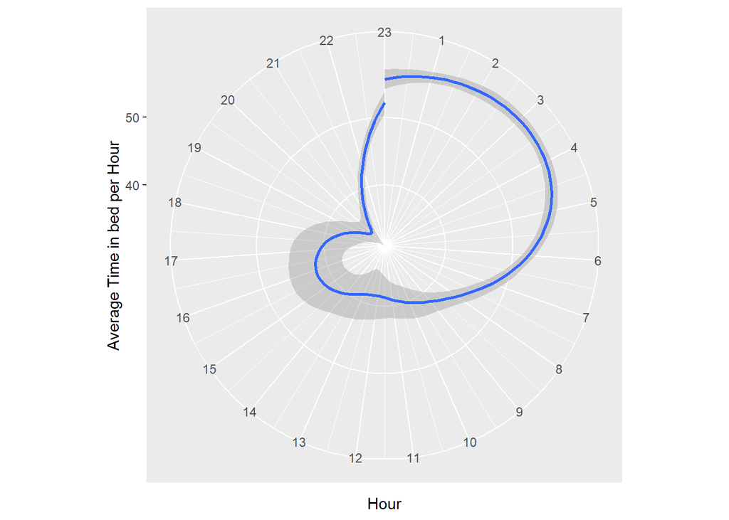

```r
ggp_sleep <- hourly_data %>% filter(MinutesInBed != -999) %>%  ggplot(aes(x=hour(ActivityHour), y=MinutesInBed))+geom_smooth() + coord_polar(start=0) + scale_x_continuous(breaks = 1:23) + xlab('Hour') + ylab('Average Time in bed per Hour')
ggp_sleep
```

#### Steps during days

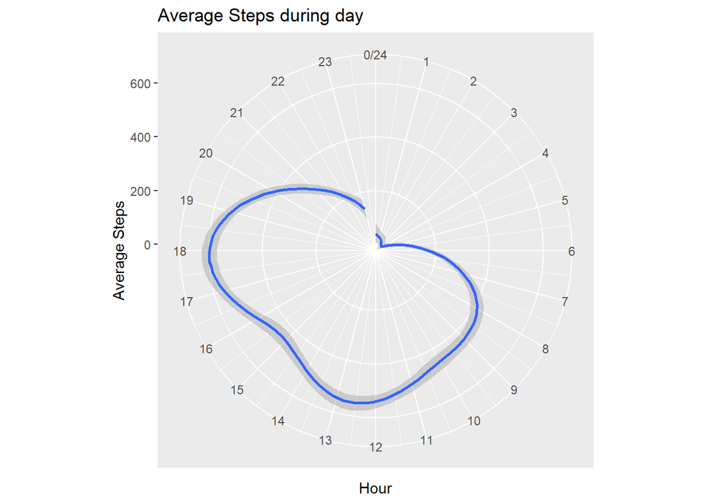

```r
ggp_steps <- hourly_data %>% ggplot(aes(x=hour(ActivityHour), y=StepTotal))+geom_smooth()+ coord_polar( start=0) + scale_x_continuous(breaks = 0:24, limits=c(0,24)) + xlab('Hour') + ylab('Average Steps') + labs(title="Average Steps during day")
ggp_steps
```

#### Calories during days

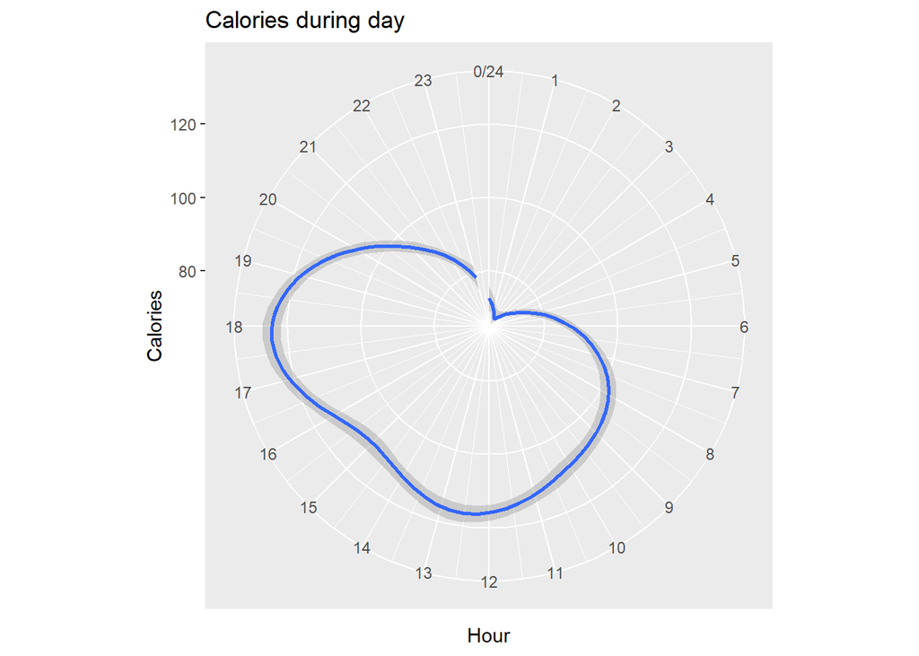

```r
ggp_cal <- hourly_data %>% filter(Calories!=-999) %>% ggplot(aes(x=hour(ActivityHour), y=Calories))+geom_smooth()+ coord_polar(clip='on', start=0) + scale_x_continuous(breaks = 0:24, limits=c(0,24)) + xlab('Hour') + ylab('Calories') + labs(title='Calories during day')
ggp_cal
```

#### Effort/METs during days

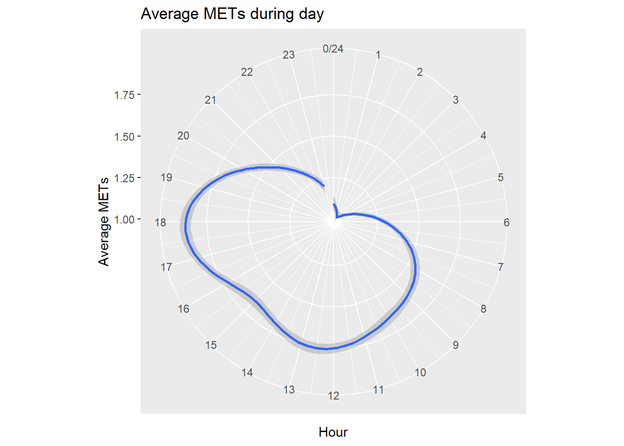

```r
ggp_cal <- hourly_data %>% filter(AverageMETs != -999) %>% ggplot(aes(x=hour(ActivityHour), y=AverageMETs))+geom_smooth()+ coord_polar(clip='on', start=0) + scale_x_continuous(breaks = 0:24, limits=c(0,24)) + xlab('Hour') + ylab('Average METs') + labs(title='Average METs during day')
ggp_cal
```

#

### But it’s not like users never run

#### Effort vs Energy Expend Rate

if we look to each minute of his days during all period, we’ll discover that they have been spent an average of:  
- **25 Days** in **Sedentary** equivalent effort.  
- **4 days** in **Light** effort.  
- **6 hours** in **Moderate** effort.  
- **10 hours** in **Vigorous** effort.

```r
options(scipen = 999)

## Filter off Id with less than 30000 entries
fltr <- minute_data %>% group_by(Id) %>% summarise(entries=n()) %>% filter(entries<30000)

## List of IDS with less than 30000 entries
id_rm <- c(2347167796,3372868164, 4057192912, 8253242879)

id_rm[1]
```

```
## [1] 2347167796
```

```r
## Filtered data
fltrd_data <- minute_data %>% filter(Id != id_rm[1]) %>%
                filter(Id != id_rm[2]) %>%
                filter(Id != id_rm[3]) %>%
                filter(Id != id_rm[4])

#fltrd_data %>% group_by(Id,Effort) %>% summarise(n())

## Number of IDS
n_ids <- length(unique(fltrd_data$Id))
min_to_hour <- 60
hour_to_day <- 24

## Show Effort in time Spent (Hours)
fltrd_data %>% group_by(Effort) %>% summarise(Average_Hours = (n()/n_ids)/(min_to_hour))
```

```
## # A tibble: 4 x 2
##   Effort    Average_Hours
##   <fct>             <dbl>
## 1 Sedentary        600.
## 2 Light             96.1
## 3 Moderate           6.91
## 4 Vigorous          10.9
```

```r
## Show Effort in time Spend (Days)
#fltrd_data %>% group_by(Effort) %>% summarise(Average_Days = (n()/n_ids)/(min_to_hour*hour_to_day))
```

### Statistics Distribuition

#### Calories

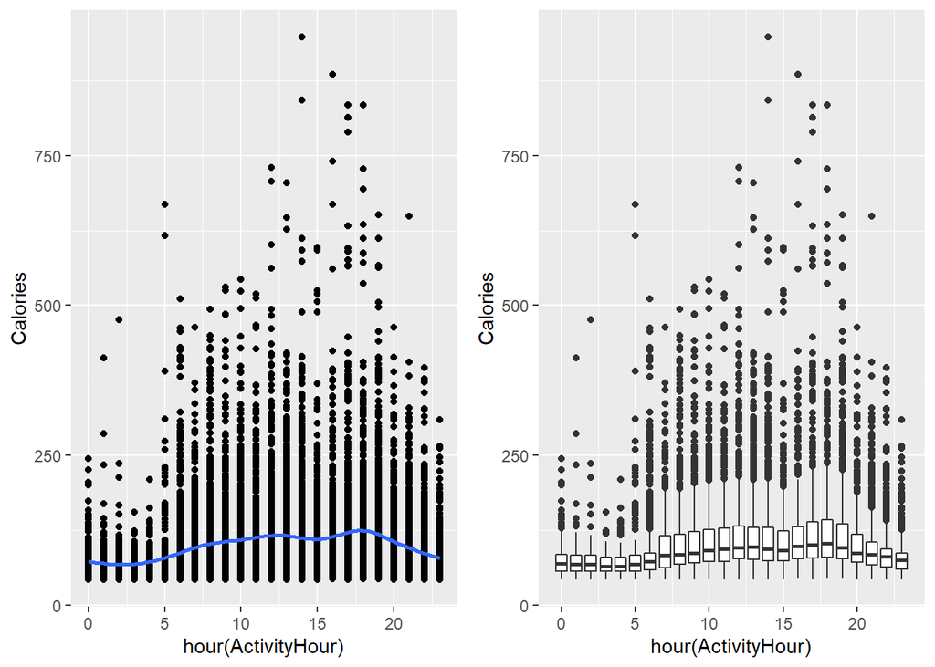

```r
ggp1 <- hourly_data %>% ggplot(aes(x=hour(ActivityHour), y=Calories),group=1) + geom_point() + geom_smooth()
ggp2 <- hourly_data %>% ggplot(aes(x=hour(ActivityHour), y=Calories),group=1) + geom_boxplot(aes(group = hour(ActivityHour)))
grid.arrange(ggp1, ggp2, ncol = 2)
```

#### Effort by hour

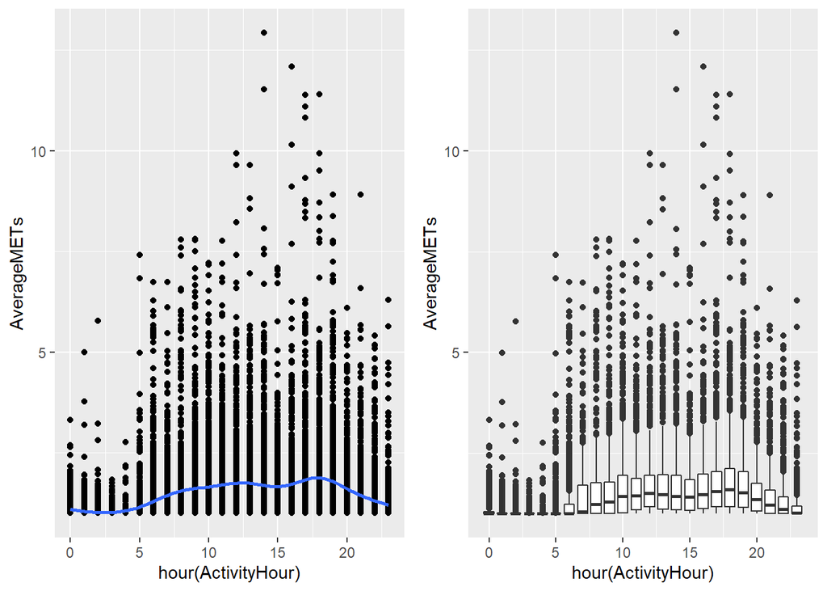

```r
ggp1 <- hourly_data %>% filter(AverageMETs != -999) %>%  ggplot(aes(hour(ActivityHour), AverageMETs)) + geom_point() + geom_smooth()
ggp2 <- hourly_data %>% filter(AverageMETs != -999) %>%  ggplot(aes(hour(ActivityHour), AverageMETs)) + geom_boxplot(aes(group = hour(ActivityHour)))
grid.arrange(ggp1, ggp2, ncol=2)
```

#### Steps by hour

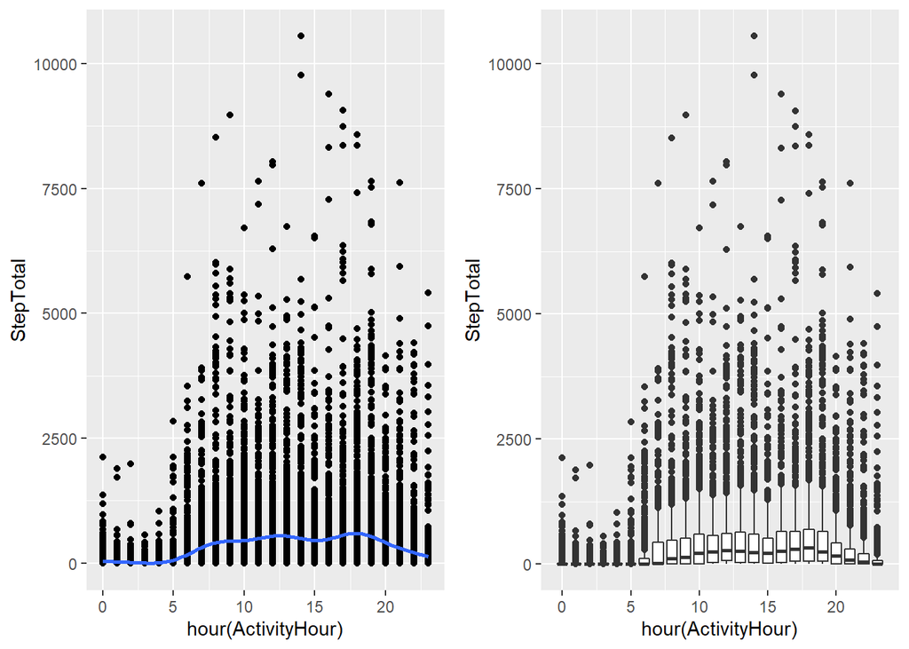

```r
ggp1 <- hourly_data %>% ggplot(aes(hour(ActivityHour), StepTotal)) + geom_point() + geom_smooth()
ggp2 <- hourly_data %>% ggplot(aes(hour(ActivityHour), StepTotal)) + geom_boxplot(aes(group = hour(ActivityHour)))
grid.arrange(ggp1, ggp2, ncol=2)
```

#### Heart rate by Hour

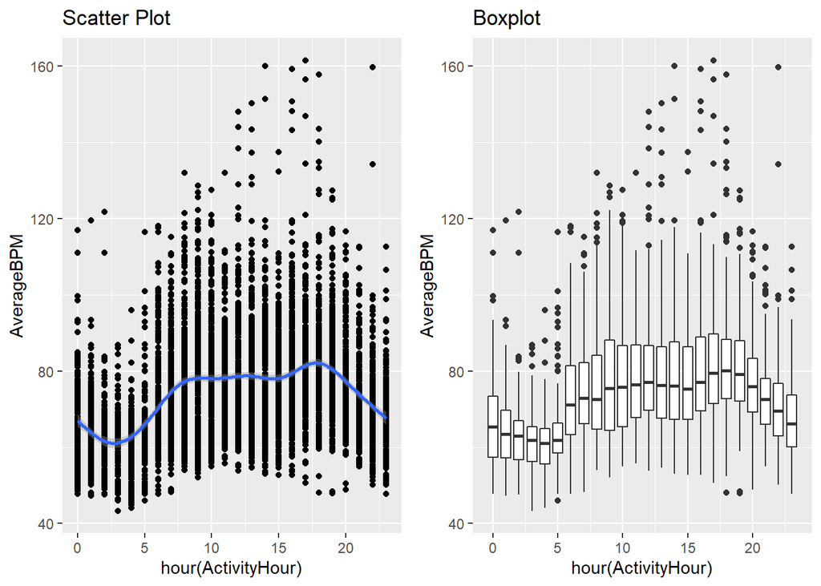

```r
ggp1 <- hourly_data %>% filter(AverageBPM != -999) %>% ggplot(aes(hour(ActivityHour),AverageBPM)) + geom_point() + geom_smooth() + labs(title='Scatter Plot' )
ggp2 <- hourly_data %>% filter(AverageBPM != -999) %>% ggplot(aes(hour(ActivityHour),AverageBPM)) + geom_boxplot(aes(group = hour(ActivityHour))) + labs(title='Boxplot' )

grid.arrange(ggp1, ggp2, ncol=2)
```

### How about the month?

#### Period trend

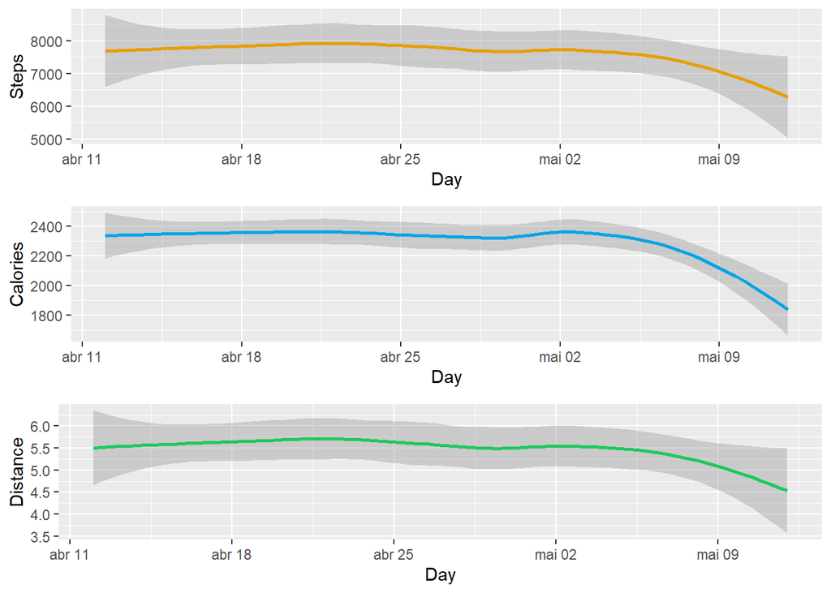

```r
ggp1 <- daily_data %>% ggplot(aes(ActivityDate, TotalSteps)) + geom_smooth(color="#E69F00", size=1) + xlab("Day") + ylab("Steps")
ggp2 <- daily_data %>% ggplot(aes(ActivityDate, Calories)) + geom_smooth(color='#00a5e6') + xlab("Day") + ylab("Calories")
ggp3 <- daily_data %>% ggplot(aes(ActivityDate, TotalDistance)) + geom_smooth(color='#1ec95d') + xlab("Day") + ylab("Distance")
grid.arrange(ggp1,ggp2,ggp3, nrow=3)
```

#### How much effort?

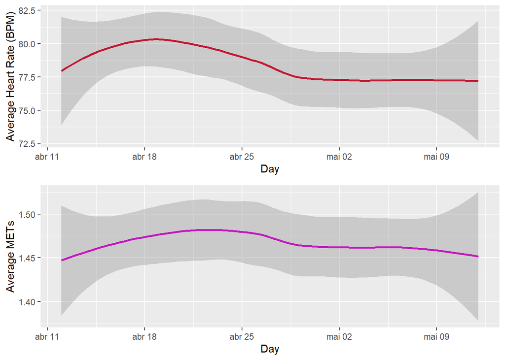

```r
ggp1 <- daily_data %>% filter(AverageBPM != -999) %>% ggplot(aes(ActivityDate, AverageBPM)) + geom_smooth(color='#c41630') + xlab('Day') + ylab("Average Heart Rate (BPM)")
ggp2 <- daily_data %>% filter(AverageMETs != -999) %>% ggplot(aes(ActivityDate, AverageMETs)) + geom_smooth(color='#c416bf') + xlab('Day') + ylab("Average METs")
grid.arrange(ggp1,ggp2, nrow=2)
```

### What’s the decisive factor to lost calories?

#### Calories and Steps

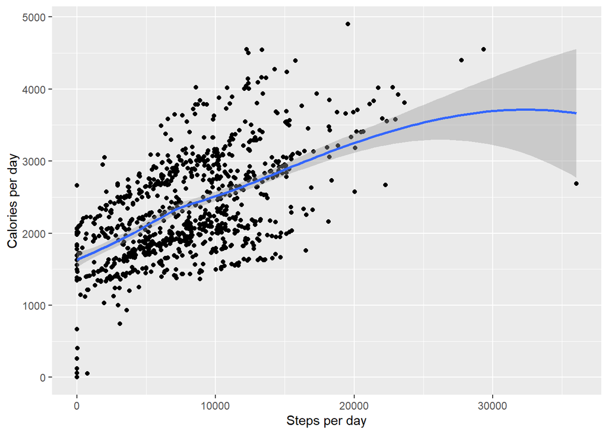

```r
ggp1 <- daily_data %>% ggplot(aes(TotalSteps, Calories)) + geom_point() + geom_smooth() + xlab('Steps per day') + ylab('Calories per day')
ggp1
```

#### Calories and Distance

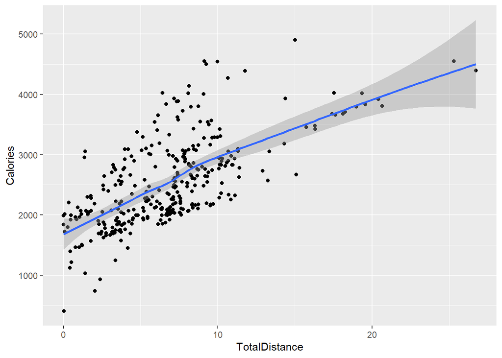

```r
ggp2 <- daily_data %>% filter(AverageBPM != -999) %>%   ggplot(aes(TotalDistance, Calories)) + geom_point() + geom_smooth()
ggp2
```

#

# Report:

They seem to be using Bella Beat devices at work or home. They are just sitting and **working**, **reading** or **studying** what is good, they’re improving themselves, building their careers. But his **health is in danger** data show that they have very **sedentary habits**. Some of them may run, ride a cycle, or goes to the gym, but the great majority are very sedentary.

We can help them, we can notify them when they spent many hours in sedentary mode, schedule exercises, help them to achieve their weight goals through calories report.

Women are more worried about their health than men, If we give them tools that help them, they’ll do the rest.

Bella Beat gadgets are very good friends of women!